# A Case Study on Retail Giant Sales/Demand Time Series Forecasting :

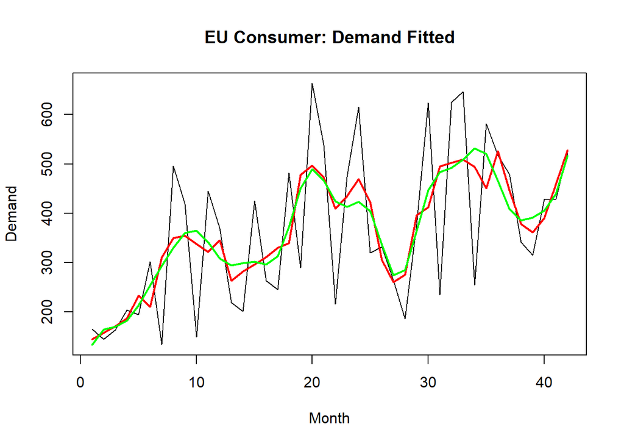

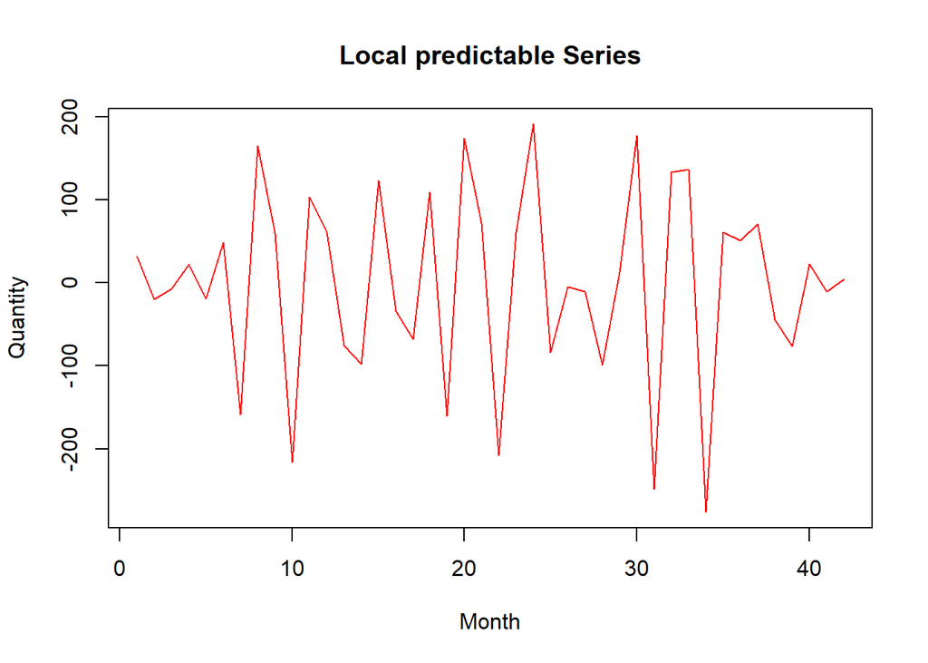

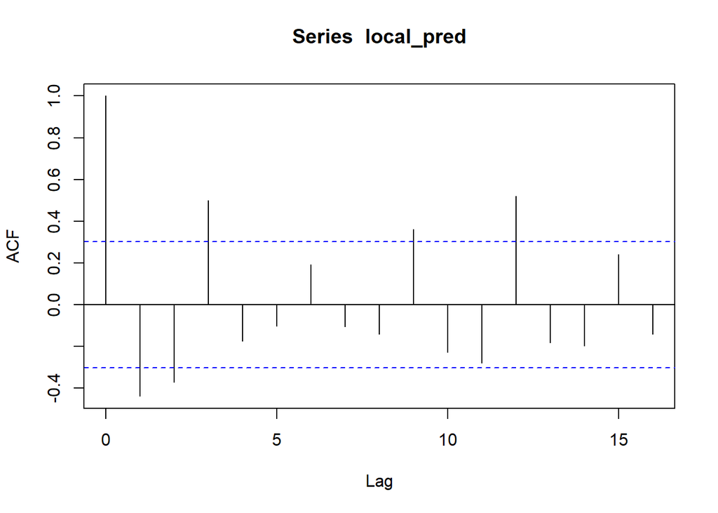

```
##
##  Augmented Dickey-Fuller Test
##
## data:  local_pred
## Dickey-Fuller = -6.122, Lag order = 3, p-value = 0.01
## alternative hypothesis: stationary
```

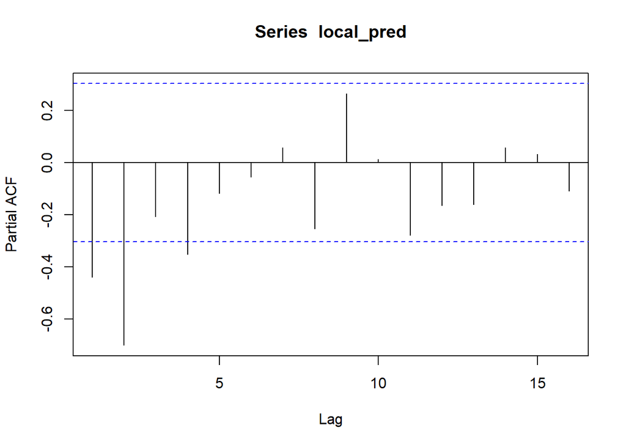

```
##
##  KPSS Test for Level Stationarity
##
## data:  local_pred
## KPSS Level = 0.019452, Truncation lag parameter = 1, p-value = 0.1
```

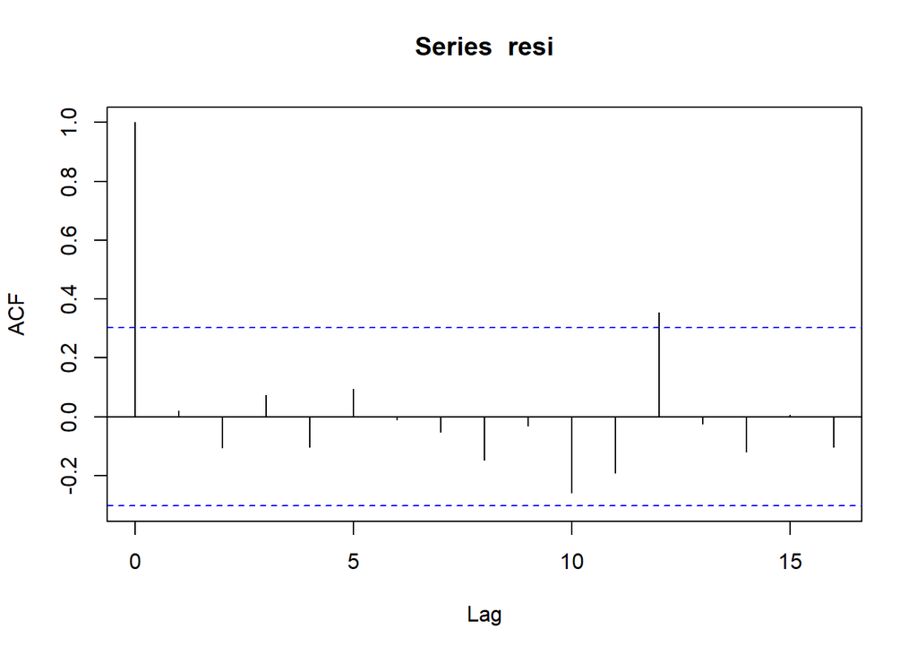

```
##
##  Augmented Dickey-Fuller Test
##
## data:  resi
## Dickey-Fuller = -3.0505, Lag order = 3, p-value = 0.1596
## alternative hypothesis: stationary
```

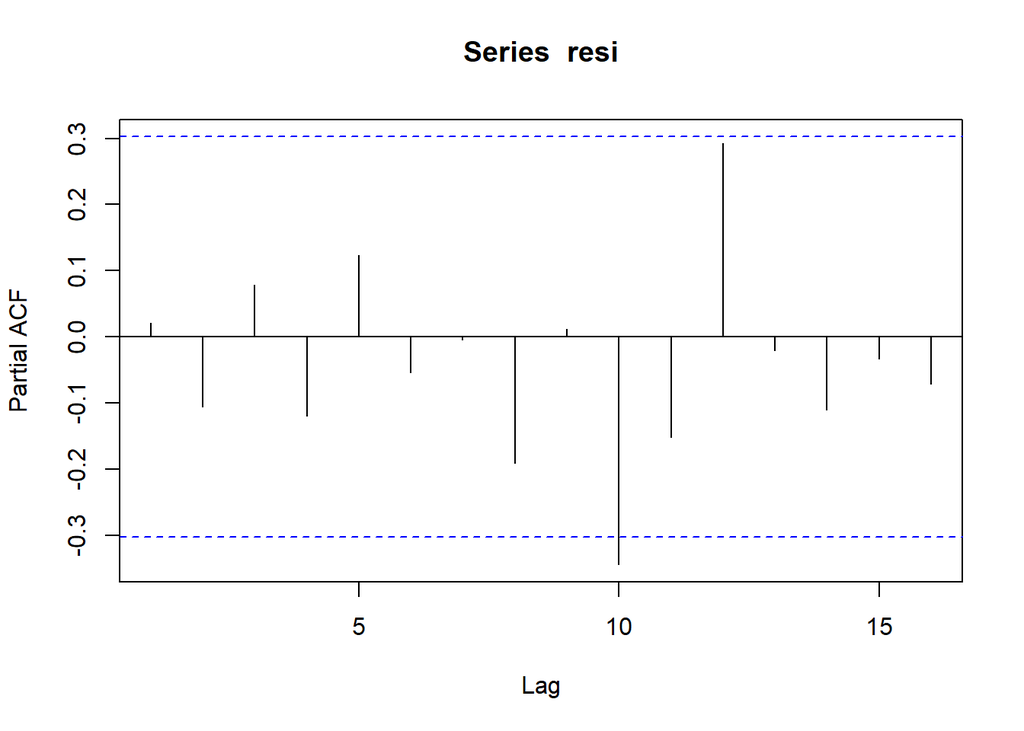

```
##
##  KPSS Test for Level Stationarity
##
## data:  resi
## KPSS Level = 0.092988, Truncation lag parameter = 1, p-value = 0.1
```

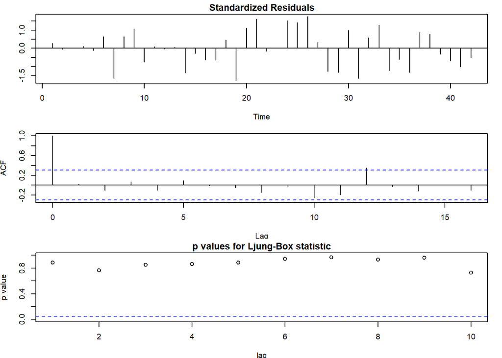

```r
plot(timeser, main = "EU Consumer: Demand Fitted",
     xlab = "Month", ylab = "Demand")
smoothedseries    <- smoothenTS(timeser, 1)
lmformula         <-  as.formula(Quantity ~ sin(Month*0.60) *
                                   cos(Month*0.60) *  poly(Month,3))
EU_Demand_model   <- buildModel(timeser, smoothedseries, lmformula, "Quantity")
```

**APAC Consumer Quantity**

```r
salesind = FALSE
timeser           <- convertTS(APAC.Consumer, salesind)
```

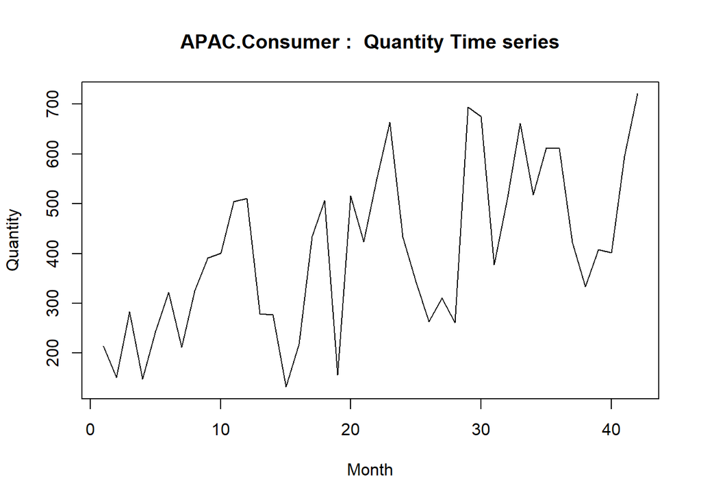

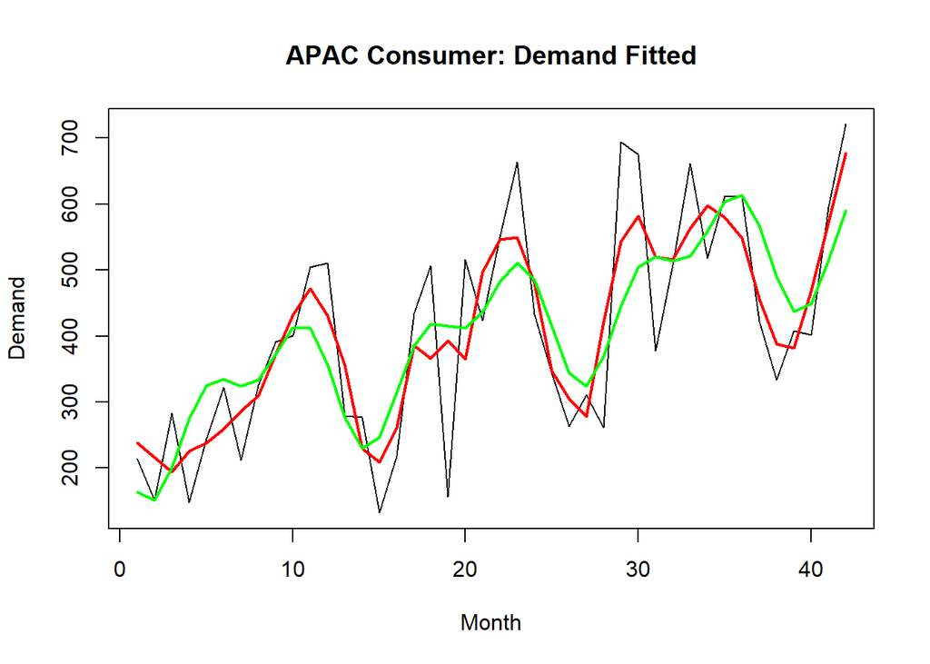

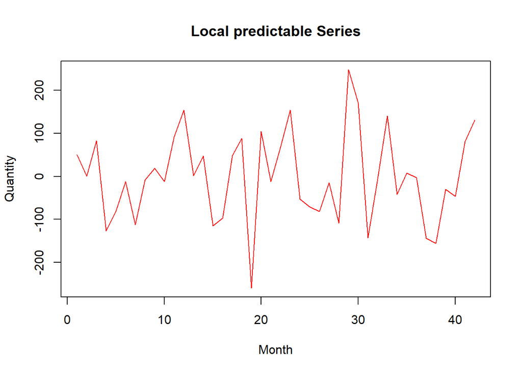

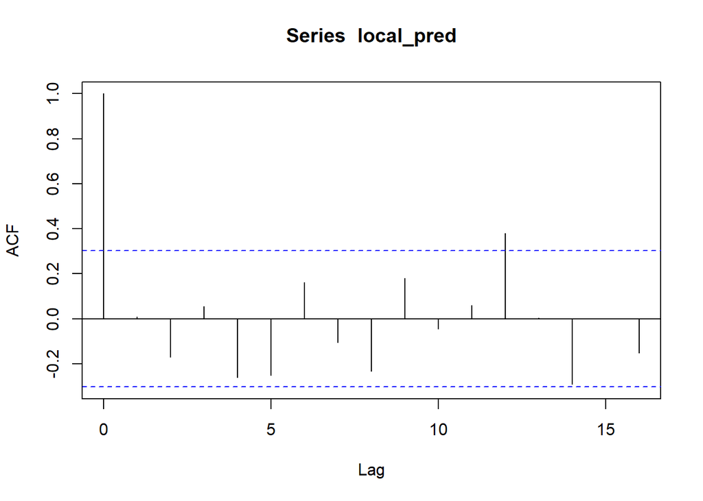

```
##
##  Augmented Dickey-Fuller Test
##
## data:  local_pred
## Dickey-Fuller = -3.9291, Lag order = 3, p-value = 0.02203
## alternative hypothesis: stationary
```

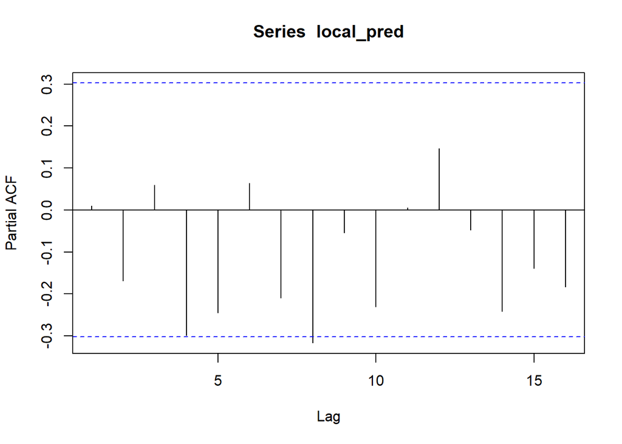

```
##
##  KPSS Test for Level Stationarity
##
## data:  local_pred
## KPSS Level = 0.034365, Truncation lag parameter = 1, p-value = 0.1
```

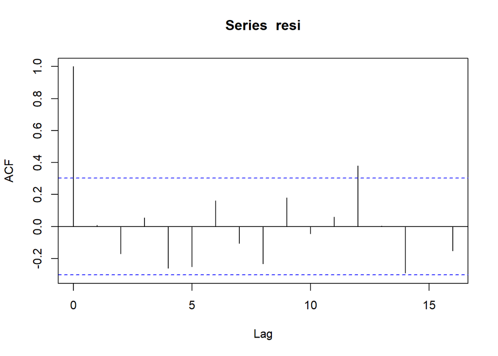

```
##
##  Augmented Dickey-Fuller Test
##
## data:  resi
## Dickey-Fuller = -3.9291, Lag order = 3, p-value = 0.02203
## alternative hypothesis: stationary
```

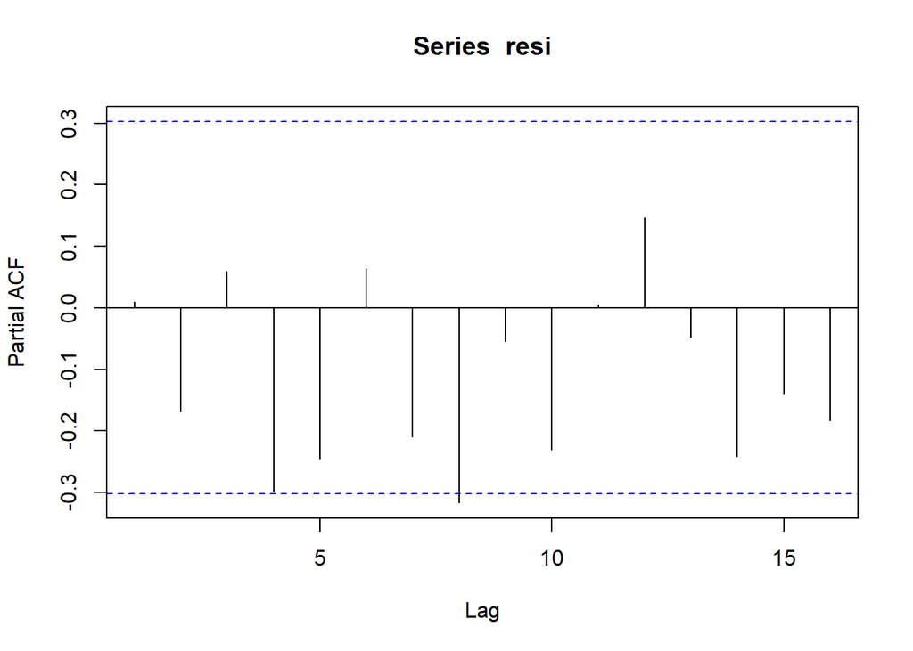

```
##
##  KPSS Test for Level Stationarity
##
## data:  resi
## KPSS Level = 0.034365, Truncation lag parameter = 1, p-value = 0.1
```

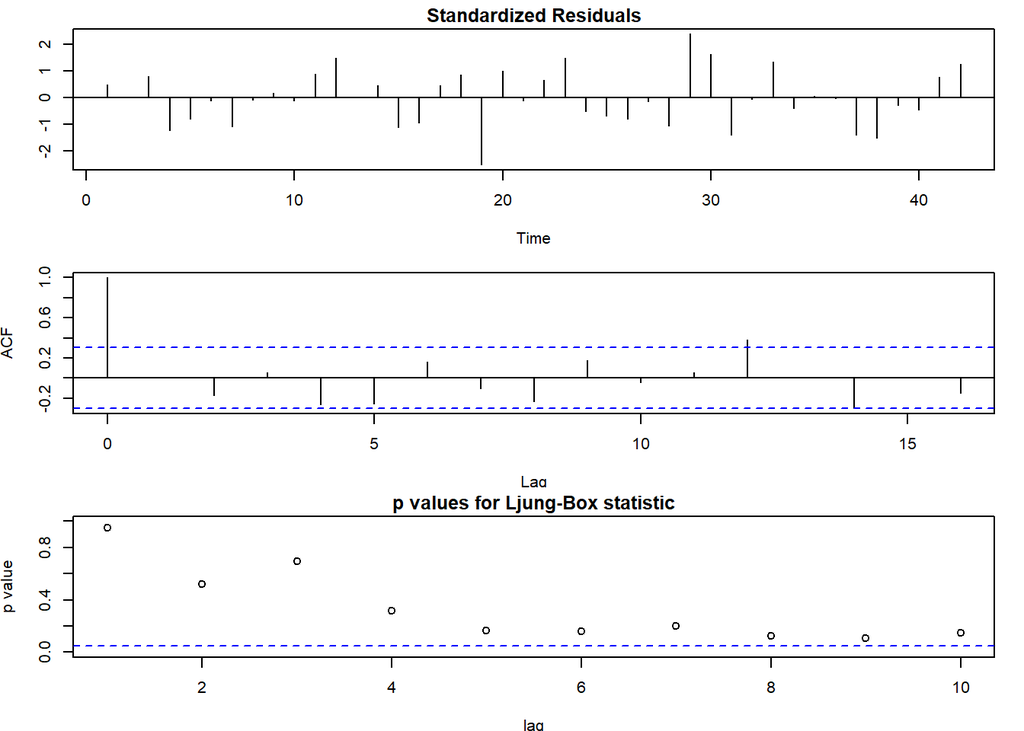

```r
plot(timeser, main = "APAC Consumer: Demand Fitted",
     xlab = "Month", ylab = "Demand")
smoothedseries    <- smoothenTS(timeser, 1)
lmformula         <-  as.formula(Quantity ~ sin(Month*0.5) *
                                   cos(Month*0.5) + poly(Month, 2))
APAC_Demand_model <- buildModel(timeser, smoothedseries, lmformula, "Quantity")
```

## Model Evaluation

Model evaluation function to predict for last 6 months and comparing against actuals using MAPE metric

```r
evaluateModel <- function(df, fittedmodel, salesind){
  # Let's evaluate the model using MAPE
  outdata <- df[43:48,]
  timevals_out <-  data.frame(Month = outdata$Month)
  fcast_arima <- predict(fittedmodel, timevals_out)
  print(fcast_arima)
  if (salesind)
    MAPE_arima <- accuracy(fcast_arima, outdata$Sales)[5]
  else
    MAPE_arima <- accuracy(fcast_arima, outdata$Quantity)[5]
  return(MAPE_arima)
}
```

**Auto Arima model building and evaluation**

```r
autoArima     <- function(df, salesind) {
  indata <- df[1:42,]
  if (salesind) {
    timeser       <- ts(indata$Sales)
    total_timeser <- ts(df$Sales)
    var = "Sales"
  } else {
    timeser       <- ts(indata$Quantity)
    total_timeser <- ts(df$Quantity)
    var = "Quantity"
  }

  auto_arima_model <- auto.arima(timeser)
  print(auto_arima_model)
  op <- par(mar = c(3.8,3.8,1.5,1.5))
  tsdiag(auto_arima_model)
  par(op)
  plot(auto_arima_model$x, col = "black",
       main = "Auto ARIMA model fitted",
       xlab = "Month", ylab = var)

  lines(fitted(auto_arima_model), col = "red")

  #Again, let's check if the residual series is white noise
  resi_auto_arima <- timeser - fitted(auto_arima_model)

  adf.test(resi_auto_arima, alternative = "stationary")
  kpss.test(resi_auto_arima)

  #Also, let's evaluate the model using MAPE
  fcast_auto_arima <- predict(auto_arima_model, n.ahead = 6)
  print(fcast_auto_arima)
  outdata <- df[43:48,]
  if (salesind)
    MAPE_auto_arima <- accuracy(fcast_auto_arima$pred,outdata$Sales)[5]
  else
    MAPE_auto_arima <- accuracy(fcast_auto_arima$pred,outdata$Quantity)[5]


  #Lastly, let's plot the predictions along with original values, to
  #get a visual feel of the fit
  auto_arima_pred <- c(fitted(auto_arima_model), ts(fcast_auto_arima$pred))
  plot(total_timeser, col = "black", main = "Auto ARIMA model forecast",
       xlab = "Month", ylab = var)
  lines(auto_arima_pred, col = "red", lwd = 2)
  #title = paste("Auto Arima model", deparse(substitute(df)), ":", var)
  return(MAPE_auto_arima)
}
```

**EU Consumer Sales**

```r
MAPE_results <-  data.frame()
salesind = TRUE
MAPE_results["EU_Sales", "CD_MAPE"]           <-
  evaluateModel(EU.Consumer, EU_Sales_model, salesind)
```

```
##        1        2        3        4        5        6
## 55965.73 59967.19 53033.26 46781.88 55095.88 72025.72
```

```
## Series: timeser
## ARIMA(2,1,0)
##
## Coefficients:
##           ar1      ar2
##       -0.5796  -0.4906
## s.e.   0.1346   0.1310
##
## sigma^2 estimated as 168564623:  log likelihood=-445.84
## AIC=897.67   AICc=898.32   BIC=902.81
```

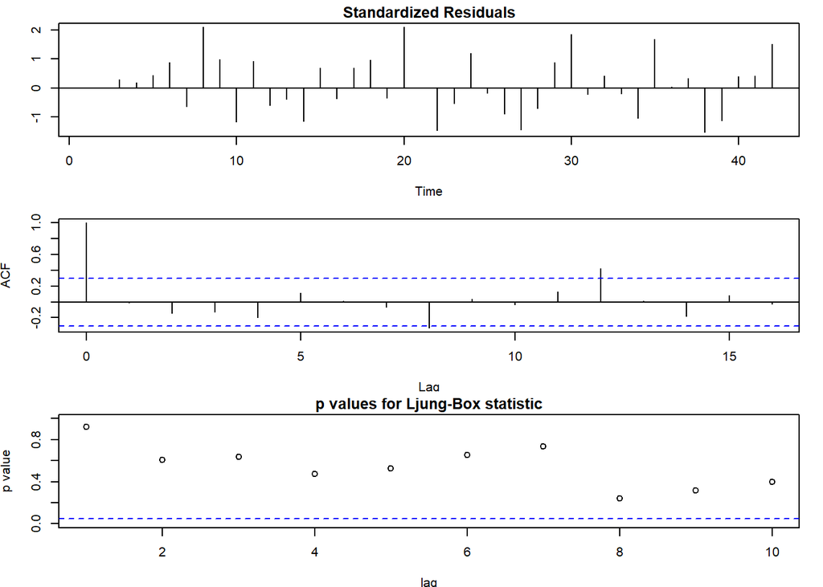

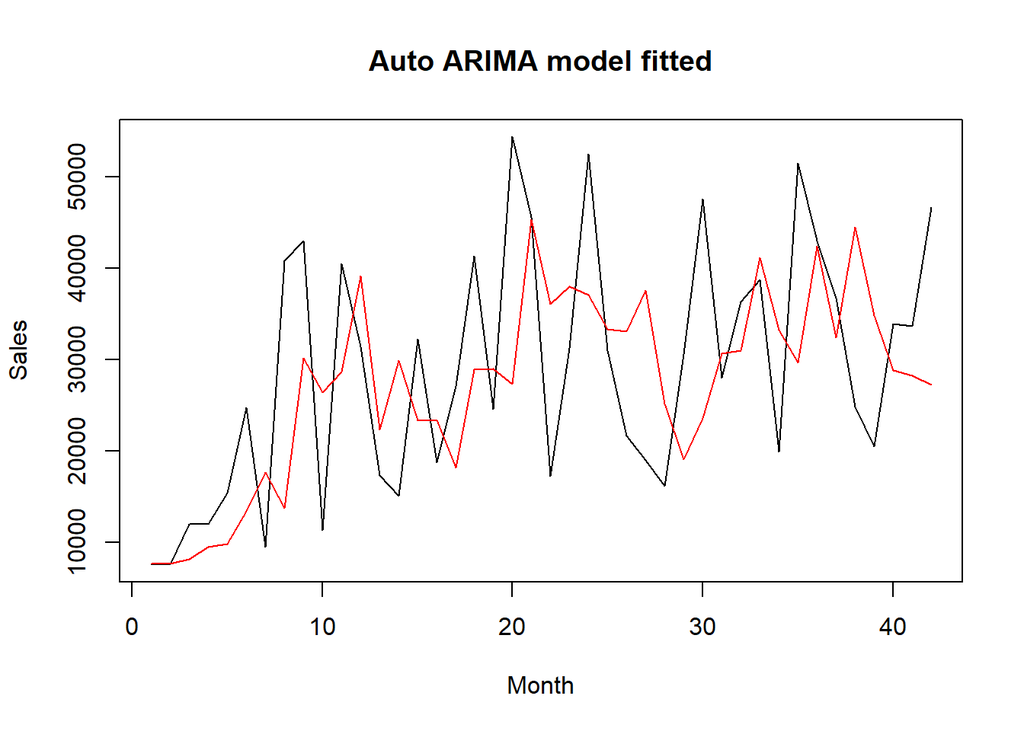

```
## $pred
## Time Series:
## Start = 43
## End = 48
## Frequency = 1
## [1] 39297.86 37221.06 42062.87 40275.32 38936.08 40589.28
##
## $se
## Time Series:
## Start = 43
## End = 48
## Frequency = 1
## [1] 12983.24 14083.80 14500.28 16710.60 17921.71 18648.29
```

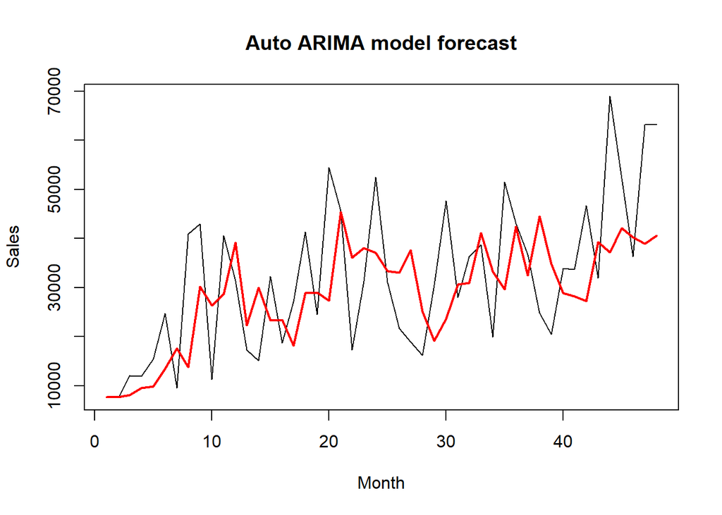

```r
MAPE_results["EU_Sales", "Auto_ARIMA_MAPE"]   <-
  autoArima(EU.Consumer, salesind)
```

**APAC Consumer Sales**

```r
salesind = TRUE
MAPE_results["APAC_Sales", "CD_MAPE"]          <-
  evaluateModel(APAC.Consumer, APAC_Sales_model, salesind)
```

```
##        1        2        3        4        5        6
## 51775.86 52192.08 52202.86 54287.98 58243.78 61102.96
```

```
## Series: timeser
## ARIMA(0,1,1)
##
## Coefficients:
##           ma1
##       -0.7559
## s.e.   0.1381
##
## sigma^2 estimated as 174361555:  log likelihood=-447.11
## AIC=898.23   AICc=898.55   BIC=901.66
```

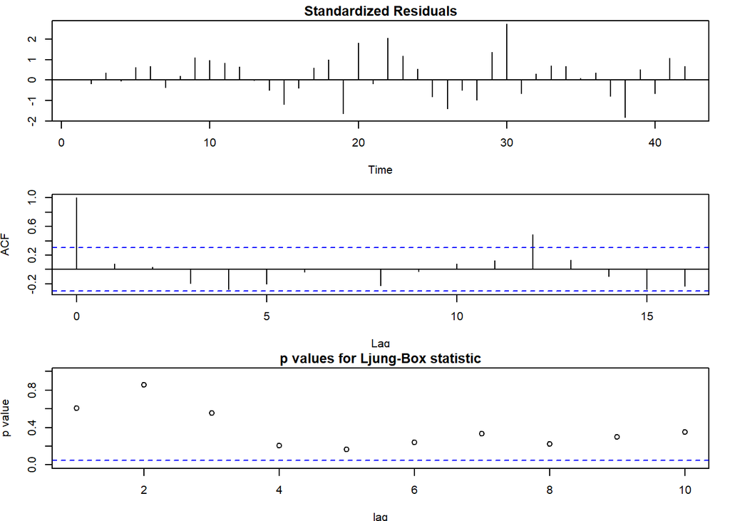

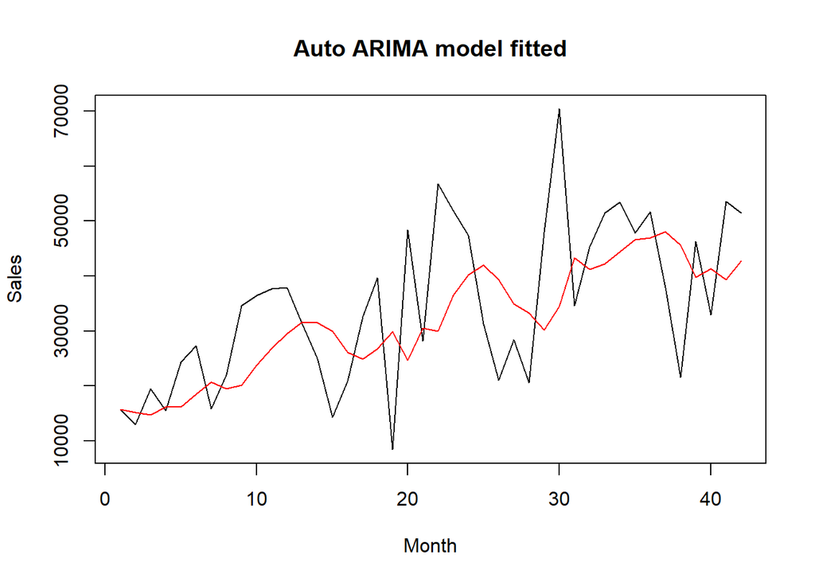

```
## $pred
## Time Series:
## Start = 43
## End = 48
## Frequency = 1
## [1] 44898.7 44898.7 44898.7 44898.7 44898.7 44898.7
##
## $se
## Time Series:
## Start = 43
## End = 48
## Frequency = 1
## [1] 13204.60 13592.40 13969.43 14336.56 14694.51 15043.95
```

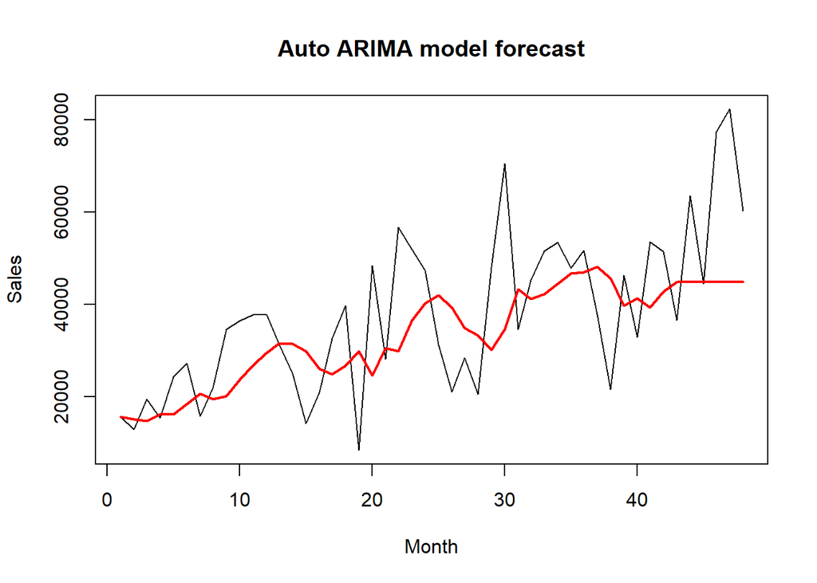

```r
MAPE_results["APAC_Sales", "Auto_ARIMA_MAPE"]  <-
  autoArima(APAC.Consumer, salesind)
```

**EU Consumer Quantity**

```r
salesind = FALSE
MAPE_results["EU_Quantity", "CD_MAPE"]          <-
  evaluateModel(EU.Consumer, EU_Demand_model, salesind)
```

```
##        1        2        3        4        5        6
## 605.3052 634.8338 597.9299 594.2603 710.4786 871.8647
```

```
## Series: timeser
## ARIMA(2,1,0)
##
## Coefficients:
##           ar1      ar2
##       -0.7359  -0.5879
## s.e.   0.1224   0.1185
##
## sigma^2 estimated as 21185:  log likelihood=-261.9
## AIC=529.8   AICc=530.44   BIC=534.94
```

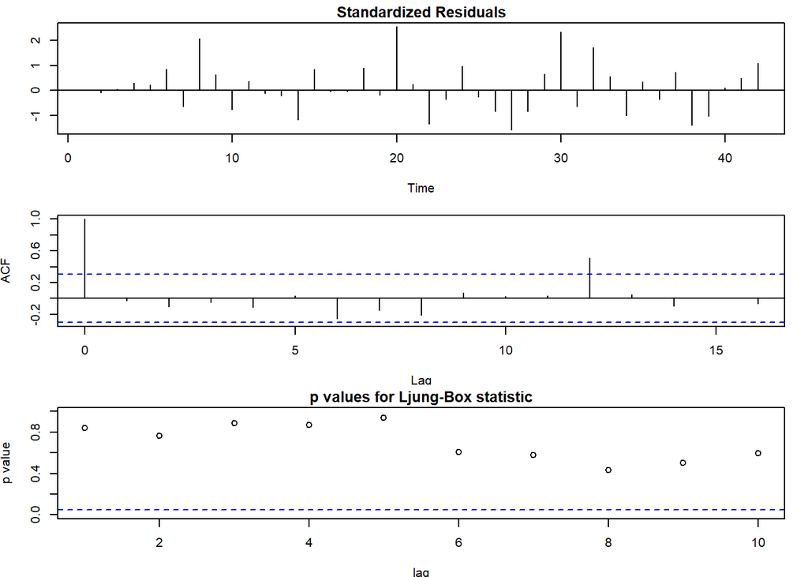

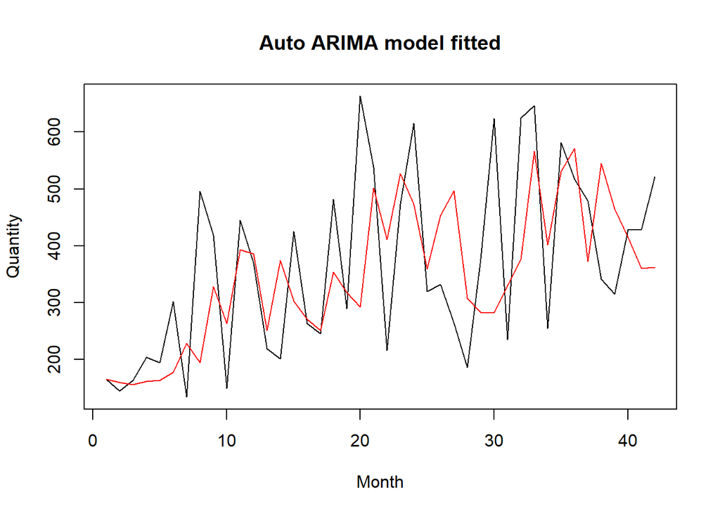

```
## $pred
## Time Series:
## Start = 43
## End = 48
## Frequency = 1
## [1] 452.7129 448.8772 491.8447 462.4816 458.8288 478.7789
##
## $se
## Time Series:
## Start = 43
## End = 48
## Frequency = 1
## [1] 145.5500 150.5419 153.8418 183.2835 190.9621 196.7892
```

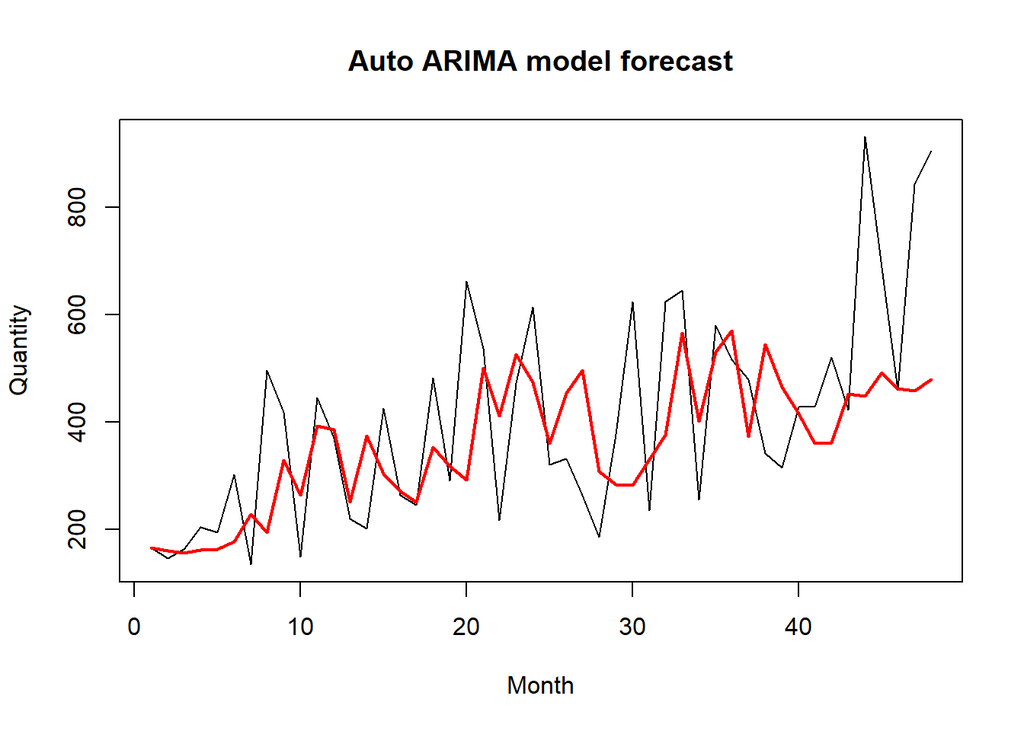

```r
MAPE_results["EU_Quantity", "Auto_ARIMA_MAPE"]  <-
  autoArima(EU.Consumer, salesind)
```

**APAC Consumer Quantity**

```r
salesind = FALSE
MAPE_results["APAC_Quantity", "CD_MAPE"]         <-
  evaluateModel(APAC.Consumer, APAC_Demand_model, salesind)
```

```
##        1        2        3        4        5        6
## 631.6447 634.6755 630.9772 653.4315 700.7992 736.3651
```

```
## Series: timeser
## ARIMA(0,1,0)
##
## sigma^2 estimated as 25366:  log likelihood=-266.07
## AIC=534.14   AICc=534.24   BIC=535.85
```

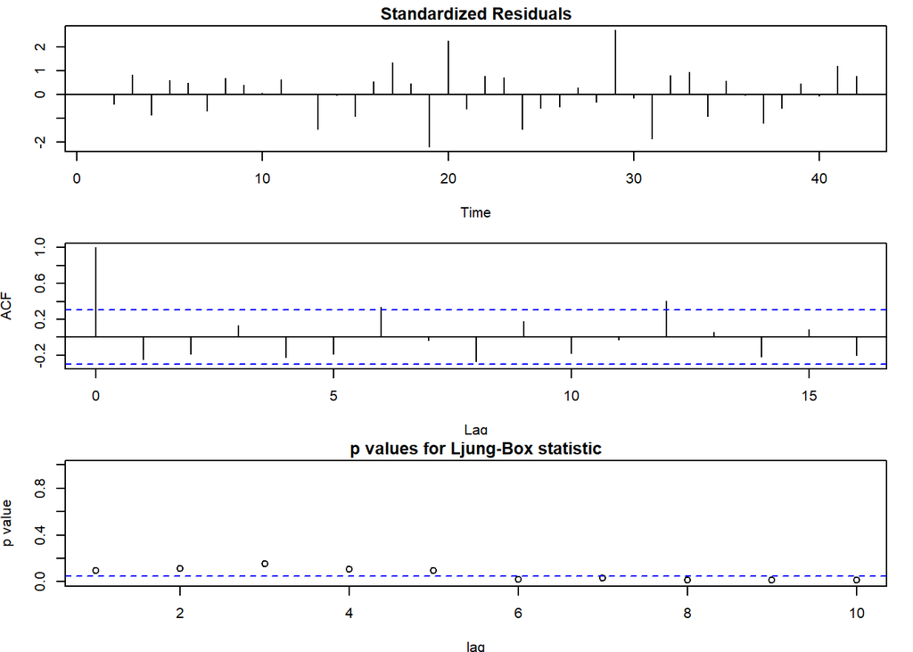

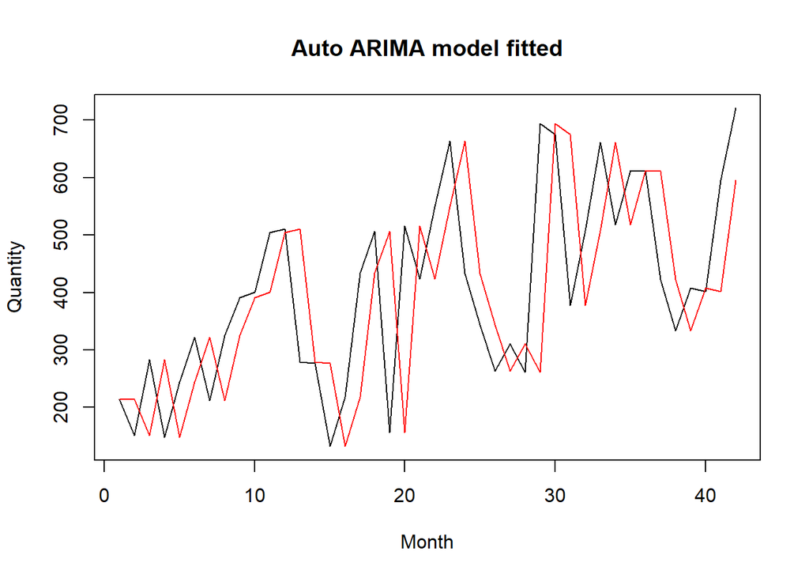

```
## $pred
## Time Series:
## Start = 43
## End = 48
## Frequency = 1
## [1] 721 721 721 721 721 721
##
## $se
## Time Series:
## Start = 43
## End = 48
## Frequency = 1
## [1] 159.2675 225.2382 275.8593 318.5349 356.1329 390.1240
```

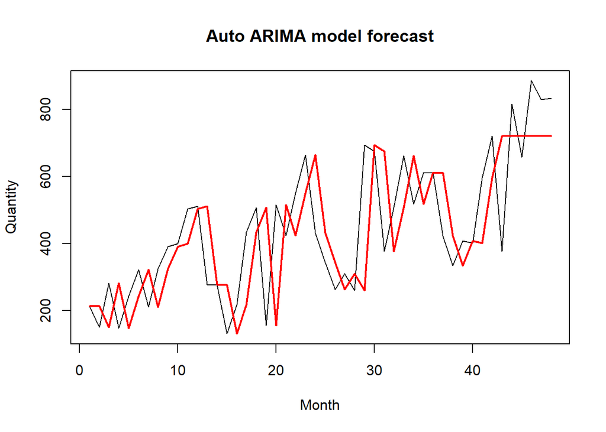

```r
MAPE_results["APAC_Quantity", "Auto_ARIMA_MAPE"] <-
  autoArima(APAC.Consumer, salesind)
```

Display MAPE values

```r
print("MAPE values using Classical decomp. & Auto Arima model: ")
```

```
## [1] "MAPE values using Classical decomp. & Auto Arima model: "
```

```r
print(MAPE_results)
```

```
##                CD_MAPE Auto_ARIMA_MAPE
## EU_Sales      24.16714        28.92260
## APAC_Sales    22.89470        27.68952
## EU_Quantity   22.82076        30.13319
## APAC_Quantity 24.51737        26.24458
```

## Final Summary

Top 2 consistently profitable Market segments based on Coeff. of Variation

1. EU-Consumer
2. APAC-Consumer

**MAPE values** for all 4 Market segment buckets using Classical Decomposition model & Auto Arima model:

| Market Segment | CD MAPE | Auto ARIMA MAPE |
| --- | --- | --- |
| EU_Sales | 24.16714 | 28.92260 |
| APAC_Sales | 22.89470 | 27.68952 |
| EU_Quantity | 22.82076 | 30.13319 |
| APAC_Quantity | 24.51737 | 26.24458 |

**Actual vs Forecast for last 6 Months in 2014:**

1.EU Consumer Sales

| Month | Jul.2014 | Aug.2014 | Sep.2014 | Oct.2014 | Nov.2014 | Dec.2014 |
| --- | --- | --- | --- | --- | --- | --- |
| Actuals | 31967.69 | 68951.72 | 52328.68 | 36348.31 | 63218.71 | 63178.60 |
| Forecast | 55965.73 | 59967.19 | 53033.26 | 46781.88 | 55095.88 | 72025.72 |

2.EU Consumer Demand

| Month | Jul.2014 | Aug.2014 | Sep.2014 | Oct.2014 | Nov.2014 | Dec.2014 |
| --- | --- | --- | --- | --- | --- | --- |
| Actuals | 423 | 932 | 688 | 459 | 843 | 905 |
| Forecast | 605 | 635 | 598 | 594 | 710 | 872 |

3.APAC Consumer Sales

| Month | Jul.2014 | Aug.2014 | Sep.2014 | Oct.2014 | Nov.2014 | Dec.2014 |
| --- | --- | --- | --- | --- | --- | --- |
| Actuals | 36524.30 | 63521.77 | 44477.27 | 77379.83 | 82286.36 | 60292.13 |
| Forecast | 51775.86 | 52192.08 | 52202.86 | 54287.98 | 58243.78 | 61102.96 |

4.APAC Consumer Demand

| Month | Jul.2014 | Aug.2014 | Sep.2014 | Oct.2014 | Nov.2014 | Dec.2014 |
| --- | --- | --- | --- | --- | --- | --- |
| Actuals | 377 | 816 | 658 | 885 | 829 | 833 |
| Forecast | 632 | 635 | 631 | 653 | 701 | 736 |